# Análisis de patrones de puntos de pedodiversidad

Carlos Manuel Guío Blanco

En este cuaderno se presenta un análisis de patrones de puntos de pedodiversidad. Se parte de los resultados del análisis exploratorio (analisis_eda_rao_colombia.Rmd), donde se identificó que que los datos de Q requieren una transformación para su uso óptimo.

## 1. Configuración

A continuación se cargan las librería necesarias

## 2. Carga de datos

Los datos producto del procesamiento, se han subido a un repositorio de Zenodo.

```r
#Carga local sin internet
#ruta_ucs_rao <- here::here("Data", "OUTPUT_rao_andina_sf.qs")
#ucs_rao_sf <- qs::qread(ruta_ucs_rao) #lectura local

# Corre script externo
source(here::here("Scripts", "carga_ucs_procesadas_qs.R"), encoding = "UTF-8")
```

```
Descargando archivo desde Zenodo con método 'curl'...
```

[output not shown]

[output cut: 152 more lines]

```
Tamaño del archivo descargado: 212.9 MB
CRS detectado: MAGNA-SIRGAS 2018 / Origen-Nacional (EPSG:9377)
```

```r
head(ucs_rao_sf)
```

```
Simple feature collection with 6 features and 15 fields
Geometry type: MULTIPOLYGON
Dimension:     XY
Bounding box:  xmin: 4558012 ymin: 1727707 xmax: 4567388 ymax: 1740702
Projected CRS: MAGNA-SIRGAS 2018 / Origen-Nacional
```

| UCSuelo | CLIMA_1 | PAISAJE | TIPO_RELIE | MATERIAL_P | SUBGRUPO | PERFILES | PORCENTAJE | HUMEDAD | AREA_HA | DES_AMB_ED | id_creado | DeNombre | geometry | Q | asignacion_igual_i |
| --- | --- | --- | --- | --- | --- | --- | --- | --- | --- | --- | --- | --- | --- | --- | --- |
| ALAa | Frío húmedo | Altiplanicie | Mesas | Cenizas volcánicas | Humic Udivitrands, Typic Udivitrands, Virtrandic Udorthents | NA164, NA161, NR50 | 45, 40, 15 | Údico | 143.60529 | Materiales de cenizas volcánicas | 1 | Nariño |  | 0.345 | FALSE |
| ALAb | Frío húmedo | Altiplanicie | Mesas | Cenizas volcánicas | Humic Udivitrands, Typic Udivitrands, Virtrandic Udorthents | NA164, NA161, NR50 | 45, 40, 15 | Údico | 154.32096 | Materiales de cenizas volcánicas | 2 | Nariño |  | 0.345 | FALSE |
| ALAb | Frío húmedo | Altiplanicie | Mesas | Cenizas volcánicas | Humic Udivitrands, Typic Udivitrands, Virtrandic Udorthents | NA164, NA161, NR50 | 45, 40, 15 | Údico | 66.51894 | Materiales de cenizas volcánicas | 3 | Nariño |  | 0.345 | FALSE |
| ALAb | Frío húmedo | Altiplanicie | Mesas | Cenizas volcánicas | Humic Udivitrands, Typic Udivitrands, Virtrandic Udorthents | NA164, NA161, NR50 | 45, 40, 15 | Údico | 449.98630 | Materiales de cenizas volcánicas | 4 | Nariño |  | 0.345 | FALSE |
| ALAb | Frío húmedo | Altiplanicie | Mesas | Cenizas volcánicas | Humic Udivitrands, Typic Udivitrands, Virtrandic Udorthents | NA164, NA161, NR50 | 45, 40, 15 | Údico | 103.28826 | Materiales de cenizas volcánicas | 5 | Nariño |  | 0.345 | FALSE |
| ALAb | Frío húmedo | Altiplanicie | Mesas | Cenizas volcánicas | Humic Udivitrands, Typic Udivitrands, Virtrandic Udorthents | NA164, NA161, NR50 | 45, 40, 15 | Údico | 75.16848 | Materiales de cenizas volcánicas | 6 | Nariño |  | 0.345 | FALSE |

Se cargan los datos de departamentos involucrados en el set de datos de pedodiversidad, para posteriormente crear la ventana de observación para el análisis.

```r
# Define ruta y nombre de capa de geopackage de departamentos
deptos_ruta <- here("Data", "INPUT_departamentos_IGAC_Abril_2025.gpkg")
capa_nombre_deptos <- sf::st_layers(deptos_ruta)$name[1]

# Carga geopackage de dpartamentos
departamentos_sf <- sf::st_read(
  deptos_ruta,
  layer = capa_nombre_deptos,
  quiet = TRUE
  ) |>
  # Se seleccionan 21 departamentos de la zona Andina, Caribe y Pacífica
  dplyr::filter(DeNombre %in% c(
    "Antioquia",
    "Atlántico",
    "Bolívar",
    "Boyacá",
    "Caldas",
    "Cauca",
    "Cesar",
    "Chocó",
    "Córdoba",
    "Cundinamarca",
    "Huila",
    "La Guajira",
    "Magdalena",
    "Nariño",
    "Norte de Santander",
    "Quindío",
    "Risaralda",
    "Santander",
    "Sucre",
    "Tolima",
    "Valle del Cauca")
    ) |>
  tidyr::drop_na()


# departamento_1_sf pasa de "SHAPE" a "geometry"
names(departamentos_sf)[names(departamentos_sf) == "SHAPE"] <- "geometry"
departamentos_sf <- sf::st_as_sf(as.data.frame(departamentos_sf), sf_column_name = "geometry")

# Aseguramos que ambos datasets tengan la misma proyección
departamentos_sf <- st_transform(departamentos_sf, st_crs(ucs_rao_sf))

# Se unen los polígonos en uno solo
limite_poly <- st_union(departamentos_sf)

# Aplica un buffer pequeño (ejemplo: 1 km) para que no queden puntos fuera
limite_buffer <- st_buffer(limite_poly, dist = 1000)
```

## 3. Pre-procesamiento

```r
ucs_rao_sf <- ucs_rao_sf |>
  #Se descartan NAs debido a polígonos que no son suelos
  tidyr::drop_na(Q) |>

  mutate(
    # se deja un mínimo diferente de cero para trabajar con logaritmos
    Q = case_when(Q == 0 ~ 1e-6, TRUE ~ Q),
    #Se calcula la densidad de Q
    Qdens = Q / AREA_HA,
    log_Qdens = log(Qdens),  # suma pequeño valor para evitar log(0)
    log_Qdens01 = (log_Qdens - min(log_Qdens, na.rm = TRUE)) /
                   (max(log_Qdens, na.rm = TRUE) - min(log_Qdens, na.rm = TRUE))
  )
```

Se genera un nuevo set de datos, utilizando el umbral máximo

```r
#Se definen dos umbrales
umbral95 <- quantile(ucs_rao_sf$log_Qdens, 0.95, na.rm = TRUE) # percentil 95
umbral05 <- quantile(ucs_rao_sf$log_Qdens, 0.05, na.rm = TRUE) # percentil 5


ucs_rao_sf <- ucs_rao_sf |>
  mutate(log_Qdens_hot95 = as.integer(log_Qdens >= umbral95),
         log_Qdens_cold5 = as.integer(log_Qdens <= umbral05)) # returna 1 = TRUE, 0 = FALSE
```

Se extraen los centroides, con marca continua y binaria.

```r
# Asegúrate de que tu objeto es tipo sf
centroides_sf <- st_centroid(ucs_rao_sf)
centroides_hot_sf <- centroides_sf[centroides_sf$log_Qdens_hot95 == 1, ]
centroides_cold_sf <- centroides_sf[centroides_sf$log_Qdens_cold5 == 1, ]
```

```r
p_mapa_centroides_marca <- ggplot() +
  geom_sf(
    data = limite_buffer,
    color = "gray90",
    fill = "gray90",
    size = 0.8,
  ) +
  geom_sf(
    data = centroides_sf,
    aes(color = log_Qdens),
    alpha = 0.7,
    size = .8,
  ) +
  scale_color_gradientn(
    name = "Log(Q/A)",
    colours = pal,
    na.value = "white",
    guide = guide_colorbar(
      direction = "horizontal",
      title.position = "left",
      title.vjust = 1,             # vertical adjustment (optional)
      barwidth = unit(4, "cm"),
      barheight = unit(0.4, "cm")
    )
  ) +
  labs(title = "Puntos de densidad de Q") +
  theme_minimal(base_size = 14) +
  theme(
    legend.position = "bottom",       # leyenda abajo
    legend.title = element_blank()    # refuerzo: sin título
  )

p_mapa_centroides_bin <- ggplot() +
  geom_sf(
    data = limite_buffer,
    color = "gray90",
    fill = "gray90",
    size = 0.8,
  ) +
  geom_sf(
    data = centroides_hot_sf,
    aes(color = "Hotspots"),
    alpha = 0.7,
    size = .8,
  ) +
  geom_sf(
    data = centroides_cold_sf,
    aes(color = "Coldspots"),
    alpha = 0.7,
    size = 0.8,
  ) +
  scale_color_manual(
    name = NULL,  # sin título de leyenda
    values = c("Hotspots" = col_hot, "Coldspots" = col_cold),
    guide = guide_legend(override.aes = list(size = 4))
  ) +
  labs(title = "Puntos críticos de densidad de Q") +
  theme_minimal(base_size = 14) +
  theme(
    legend.position = "bottom",       # leyenda abajo
    legend.title = element_blank()    # refuerzo: sin título
  )

p_mapa_centroides_hot <- ggplot() +
  geom_sf(
    data = limite_buffer,
    color = "gray90",
    fill = "gray90",
    size = 0.8,
  ) +
  geom_sf(
    data = centroides_hot_sf,
    aes(color = "Hotspots"),
    alpha = 0.7,
    size = .8,
  ) +
  scale_color_manual(
    name = NULL,  # sin título de leyenda
    values = c("Hotspots" = col_hot),
    guide = guide_legend(override.aes = list(size = 4))
  ) +
  labs(title = "Puntos de alta densidad de Q") +
  theme_minimal(base_size = 14) +
  theme(
    legend.position = "bottom",       # leyenda abajo
    legend.title = element_blank()    # refuerzo: sin título
  )

p_mapa_centroides_cold <- ggplot() +
    geom_sf(
    data = limite_buffer,
    color = "gray90",
    fill = "gray90",
    size = 0.8,
  ) +
  geom_sf(
    data = centroides_cold_sf,
    aes(color = "Coldspots"),
    alpha = 0.7,
    size = 0.8,
  ) +
  scale_color_manual(
    name = NULL,  # sin título de leyenda
    values = c("Coldspots" = col_cold),
    guide = guide_legend(override.aes = list(size = 4))
  ) +
  labs(title = "Puntos de baja densidad de Q") +
  theme_minimal(base_size = 14) +
  theme(
    legend.position = "bottom",       # leyenda abajo
    legend.title = element_blank()    # refuerzo: sin título
  )

p_mosaico_puntos_criticos <- p_mapa_centroides_hot + p_mapa_centroides_cold + p_mapa_centroides_bin + p_mapa_centroides_marca + plot_layout(ncol = 4)
```

|  | t | l | b | r |
| --- | --- | --- | --- | --- |
| 1: | 1 | 1 | 1 | 1 |
| 2: | 2 | 1 | 2 | 1 |
| 3: | 1 | 2 | 1 | 2 |
| 4: | 2 | 2 | 2 | 2 |

```r
#guarda el último gráfico generado
ggsave(here("Figures", "mapas_Qdens_puntos_criticos.png"),
       plot = p_mosaico_puntos_criticos,
       width = 17,
       height = 7,
       dpi = 350)
```

Se definen la ventana de observación y se crean los objetos ppp (de la librería spatstats). La ventana de observación corresponde al polígono, y no a una forma rectangualr, que generaría “escaneo” en áreas vacías.

```r
# Convierte el polígono a un objeto 'owin' (ventana de spatstat)
W <- as.owin(limite_buffer)

# Extrae las coordenadas de los puntos como X y Y
centroides_hot_coords <- st_coordinates(centroides_hot_sf)
centroides_cold_coords <- st_coordinates(centroides_cold_sf)


# 3. Crea objetos ppp
pp_hot <- ppp(x = centroides_hot_coords[,1], y = centroides_hot_coords[,2], window = W)
pp_cold <- ppp(x = centroides_hot_coords[,1], y = centroides_hot_coords[,2], window = W)
```

## 4. Resumenes estadísticos de puntos

### 4.1 Modelo univariado homogéneo k Ripley para hotspots y coldspots

Restringir la escala r -i.e rango- mínima y máxima de análisis mejora la interpretación, la estabilidad estadística y también reduce el tiempo de cálculo. Según Wiegand & Moloney (2014), se recomienda utilizar menos de la mitad de la dimensión mas pequeña de la bounding box.

El parámetro r representa la distancia espacial a la que se evalúa el agrupamiento/repulsión entre puntos. Por defecto, Kest() usa una secuencia automática desde 0 hasta aproximadamente el máximo posible dentro de la ventana. Si no se ajusta, los valores altos de r (distancias grandes) pueden verse afectados por efectos de borde.

```r
# Calculo de r máximo de acuerdo a bbox/2
bbox <- st_bbox(W)
```

[output not shown]

Se generan los gráficos básicos de spatstat. Para interpretar:

K̂_iso(r) (negro): Es la estimación “isotrópica” estándar de la función K. Usa corrección de borde isotrópica y es la más utilizada.

K̂_trans(r) (rojo punteado): Es la estimación de K usando la corrección “translation” (traducción). Suele ser más precisa en ventanas irregulares/grandes.

K̂_bord(r) (verde punteado): Es la estimación de K usando la corrección “border” (borde). Menos robusta para ventanas muy irregulares o datos escasos en los bordes.

K_pois(r) (azul punteado):Es la curva K esperada bajo el modelo de completa aleatoriedad espacial (CSR) (proceso de Poisson homogéneo). Es la referencia “nula” contra la cual se compara el agrupamiento real de los puntos.

[figure not shown]

```r
plot(K_hot)
```

A continuación se genera un intervalo de confianza (envolvente). Esto genera n simulaciones nulas (CSR) y calcula los valores mínimos y máximos para cada r. La función envelope() también calcula la curva observada con las correcciones iso, border y trans, pero se debe escoger una de estas, por l oque se aconseja correr primero Kest a modo exploratorio. Por otro lado, envelope() no calcula la curva teórica (de la distribución de Poisson), sino que calcula una media equivalente para las simulaciones.

```r
# nsim = número de simulaciones
# rank = ancho del envelope (para bandas de confianza 95%, usa rank = 2.5 para 2.5% y 97.5%)
env_hot <- envelope(
  pp_hot,
  r = rseq_bbox,   # <-- Esta línea asegura que el rango de r es igual a kest()
  fun = Kest,
  nsim = 100,        # número de simulaciones
  rank = 2.5,         # para envelope máximo/mínimo = 1; para bandas tipo 95% usa rank = 2.5
  simulate = expression(rpoispp(lambda = intensity(pp_hot), win = pp_hot$window)),
  savefuns = TRUE,  # guarda las simulaciones individuales por si quieres verlas
  correction = "trans" # puedes especificar otro si prefieres (ej. "trans", "iso", "bord")
)
```

```
Generating 100 simulations by evaluating expression  ...
1, 2, 3, 4, 5, 6, 7, 8, 9, 10, 11, 12, 13, 14, 15, 16, 17, 18, 19, 20, 21, 22,
23, 24, 25, 26, 27, 28, 29, 30, 31, 32, 33, 34, 35, 36, 37, 38, 39, 40, 41, 42, 43, 44,
45, 46, 47, 48, 49, 50, 51, 52, 53, 54, 55, 56, 57, 58, 59, 60, 61, 62, 63, 64, 65, 66,
67, 68, 69, 70, 71, 72, 73, 74, 75, 76, 77, 78, 79, 80, 81, 82, 83, 84, 85, 86, 87, 88,
89, 90, 91, 92, 93, 94, 95, 96, 97, 98, 99,
100.

Done.
```

```r
env_cold <- envelope(
  pp_cold,
  r = rseq_bbox,   # <-- Esta línea asegura que el rango de r es igual a kest()
  fun = Kest,
  nsim = 100,        # número de simulaciones
  rank = 2.5,         # para envelope máximo/mínimo = 1; para bandas tipo 95% usa rank = 2.5
  simulate = expression(rpoispp(lambda = intensity(pp_hot), win = pp_hot$window)),
  savefuns = TRUE,  # guarda las simulaciones individuales por si quieres verlas
  correction = "trans" # puedes especificar otro si prefieres (ej. "trans", "iso", "bord")
)
```

```
Generating 100 simulations by evaluating expression  ...
1, 2, 3, 4, 5, 6, 7, 8, 9, 10, 11, 12, 13, 14, 15, 16, 17, 18, 19, 20, 21, 22,
23, 24, 25, 26, 27, 28, 29, 30, 31, 32, 33, 34, 35, 36, 37, 38, 39, 40, 41, 42, 43, 44,
45, 46, 47, 48, 49, 50, 51, 52, 53, 54, 55, 56, 57, 58, 59, 60, 61, 62, 63, 64, 65, 66,
67, 68, 69, 70, 71, 72, 73, 74, 75, 76, 77, 78, 79, 80, 81, 82, 83, 84, 85, 86, 87, 88,
89, 90, 91, 92, 93, 94, 95, 96, 97, 98, 99,
100.

Done.
```

A continuación se grafican los resultados de K de Ripley para coldspots y hotspots. Se utilizan los datos de envelope

```r
# Transforma en df (spatstats exporta como "envelope"   "fv" y generan conflicto en ggplot)
# Los campos relevantes: r (distancia), obs (observado), theo (teórico), lo (mínimo simulado), hi (máximo simulado)
env_hot_df <- as_tibble(env_hot)
env_cold_df <- as_tibble(env_cold)


# Hotspots con leyenda
p_hot <- ggplot(env_hot_df, aes(x = r)) +
  geom_ribbon(aes(ymin = lo, ymax = hi), fill = "grey80", alpha = 0.6) +
  geom_line(aes(y = obs, color = "Observada"), size = 1.2) +
  geom_line(aes(y = mmean, color = "Nulo CSR"), linetype = "dashed", size = 1) +
  scale_color_manual(
    name = "Curva",
    values = c("Observada" = col_hot, "Nulo CSR" = "black")
  ) +
  labs(
    title = "Curva K (trans) Hotspots",
    x = "Distancia r",
    y = "K(r)"
  ) +
  theme_minimal(base_size = 14)

# Coldspots con leyenda
p_cold <- ggplot(env_cold_df, aes(x = r)) +
  geom_ribbon(aes(ymin = lo, ymax = hi), fill = "grey80", alpha = 0.6) +
  geom_line(aes(y = obs, color = "Observada"), size = 1.2) +
  geom_line(aes(y = mmean, color = "Nulo CSR"), linetype = "dashed", size = 1) +
  scale_color_manual(
    name = "Curva",
    values = c("Observada" = col_cold, "Nulo CSR" = "black")
  ) +
  labs(
    title = "Curva K (trans) Coldspots",
    x = "Distancia r",
    y = "K(r)"
  ) +
  theme_minimal(base_size = 14)

# Mosaico
p_mosaico_kripley_univ_homogeneo <- p_hot + p_cold + plot_layout(ncol = 1)
```

|  | t | l | b | r |
| --- | --- | --- | --- | --- |
| 1: | 1 | 1 | 1 | 1 |
| 2: | 1 | 2 | 1 | 2 |

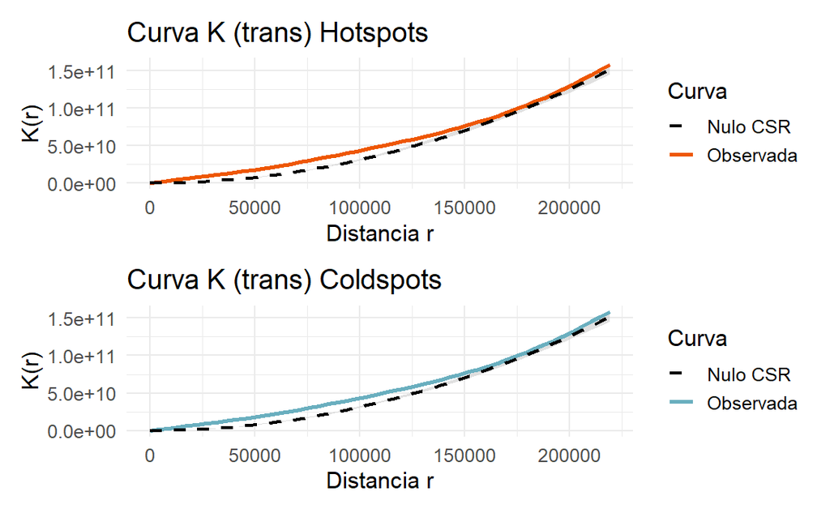

```r
p_mosaico_kripley_univ_homogeneo

#guarda el último gráfico generado
ggsave(here("Figures", "mosaico_kripley_univ_homogeneo.png"),
       plot = p_mosaico_kripley_univ_homogeneo,
       width = 8,
       height = 10,
       dpi = 350)
```

### 4.2 Modelo univariado inhomogéneo k Ripley para hotspots y coldspots

En vez de asumir que los puntos (centroides) son igualmente probables en cualquier parte del espacio (CSR), se ajusta la intensidad esperada de aparición de puntos usando la información de área.

Como la probabilidad de aparición de puntos (centroides) debería ser inversamente proporcional al área del polígono que representa, se puede definir una intensidad estimada por punto. Se utilizan los datos completos para crear una superficie continua, para usarla como input de kinhom(). Se utiliza unatransformación de raiz cuadrada para el area, ya que ni 1/A ni 1/log(A) dió contraste suficiente.Dado que la superficie de áreas es única para todo el conjunto, se calcula con los datos de centroides del conjunto completo.

```r
#Se utiliza la misma ventana de observación (polígono + buffer)
pp_centroides <- ppp(x = coords[,1], y = coords[,2], window = W, marks = centroides_sf$lambda_area)
```

Se grafica en ggplot comparando lambda con los puntos. Se observa que el Kernel multiplica los valores de forma negativa.

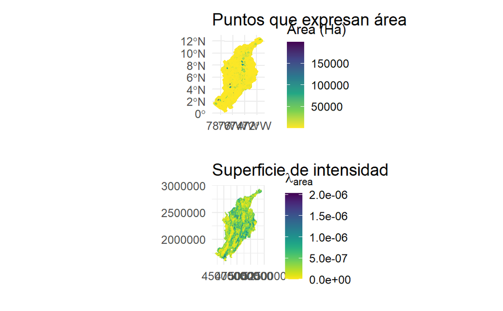

```r
# Convierte la imagen a data.frame
lambda_area_df <- as.data.frame(lambda_im)
colnames(lambda_area_df) <- c("x", "y", "lambda_area")

# Elimina NA (fuera del polígono)
lambda_area_df <- lambda_area_df[!is.na(lambda_area_df$lambda_area), ]

#Plot de superficie lambda
p_raster_lambda_area <- ggplot(lambda_area_df, aes(x = x, y = y, fill = lambda_area)) +
  geom_raster(interpolate = TRUE) +
  scale_fill_viridis(
    option = "viridis",
    direction = -1,
    name = expression(lambda[area])
    ) +
  coord_equal() +
  labs(
    title = "Superficie de intensidad",
    x = "", y = ""
  ) +
  theme_minimal(base_size = 14)

# Plot de puntos
p_puntos_lambda_area <- ggplot(centroides_sf) +
  geom_sf(aes(color = AREA_HA), size = 1) +
  scale_color_viridis_c(
    name = "Área (Ha)",
    option = "viridis",
    direction = -1) +
  labs(
    title = "Puntos que expresan área",
    x = "", y = ""
  ) +
  theme_minimal(base_size = 14)

p_lambda_area <- p_puntos_lambda_area / p_raster_lambda_area

p_lambda_area

#guarda el gráfico generado
ggsave(here("Figures", "lambda_area_inhomogeneo.png"),
       plot = p_lambda_area,
       width = 8,
       height = 12,
      dpi = 350)
```

Se corre el modelo de Kinhom con la superficie de intensidad inversa a la raíz del área, para ambos conjuntos de datos

```r
Kinhom_area_hot <- Kinhom(pp_hot, lambda = lambda_im, r = rseq_bbox)
```

```
number of data points exceeds 1000 - computing border correction estimate only
```

```r
Kinhom_area_cold <- Kinhom(pp_cold, lambda = lambda_im, r = rseq_bbox)
```

```
number of data points exceeds 1000 - computing border correction estimate only
```

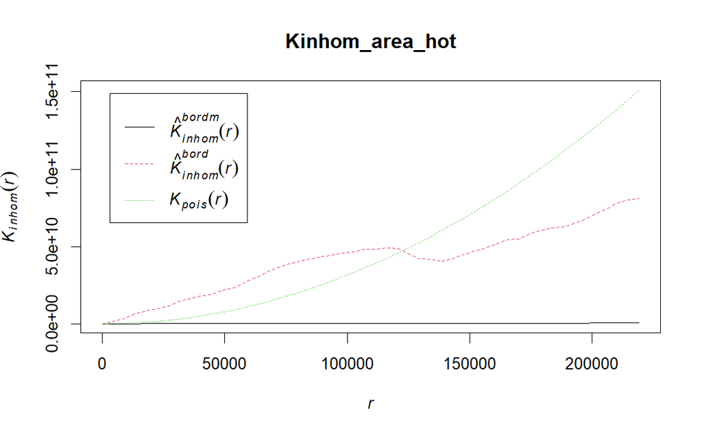

```r
plot(Kinhom_area_hot)
```

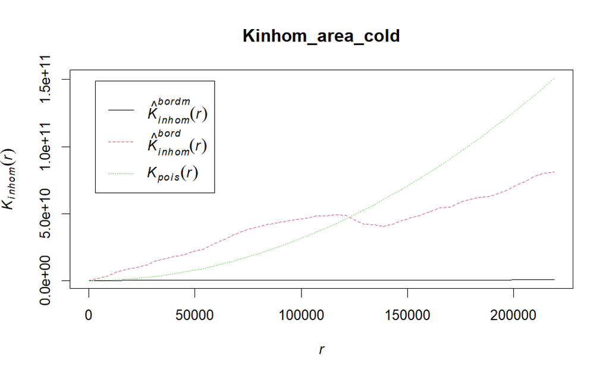

```r
plot(Kinhom_area_cold)
```

Para Kinhom, las envolventes no dan muy buenos resultados, pues no reflejan el modelo sin envolventes. No se muestran acá.

```r
Kinhom_hot_df <- as_tibble(Kinhom_area_hot)  # o Kinhom_area_cold
Kinhom_cold_df <- as_tibble(Kinhom_area_cold)

p_kinhom_hot <- ggplot(Kinhom_hot_df, aes(x = r)) +
  geom_line(aes(y = border, color = "Observada (inhom.)"), size = 1.2) +
  geom_line(aes(y = theo, color = "Nulo inhom."), linetype = "dashed", size = 1) +
  scale_color_manual(
    name = "Curva",
    values = c("Observada (inhom.)" = col_hot, "Nulo inhom." = "black")
  ) +
  labs(
    title = "Curva Kinhom Hotspots (corregida por área)",
    x = "Distancia r",
    y = "Kinhom(r)"
  ) +
  #xlim(0, 20000) +
  theme_minimal(base_size = 14)

p_kinhom_cold <- ggplot(Kinhom_cold_df, aes(x = r)) +
  geom_line(aes(y = border, color = "Observada (inhom.)"), size = 1.2) +
  geom_line(aes(y = theo, color = "Nulo inhom."), linetype = "dashed", size = 1) +
  scale_color_manual(
    name = "Curva",
    values = c("Observada (inhom.)" = col_cold, "Nulo inhom." = "black")
  ) +
  labs(
    title = "Curva Kinhom Coldspots (corregida por área)",
    x = "Distancia r",
    y = "Kinhom(r)"
  ) +
  #xlim(0, 20000) +
  theme_minimal(base_size = 14)

# Mosaico
p_mosaico_kripley_univ_inhomogeneo <- p_kinhom_hot + p_kinhom_cold + plot_layout(ncol = 1)
```

|  | t | l | b | r |
| --- | --- | --- | --- | --- |
| 1: | 1 | 1 | 1 | 1 |
| 2: | 1 | 2 | 1 | 2 |

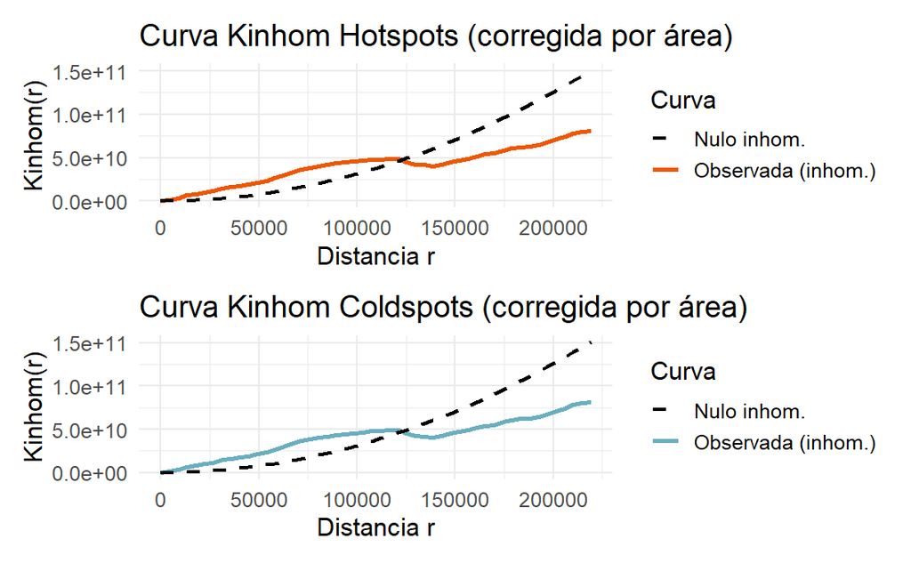

```r
p_mosaico_kripley_univ_inhomogeneo

#guarda el último gráfico generado
ggsave(here("Figures", "mosaico_kripley_univ_inhomogeneo.png"),
       plot = p_mosaico_kripley_univ_inhomogeneo,
       width = 8,
       height = 10,
       dpi = 350)
```

### 4.3 Modelo bivariado inhomogéneo

```r
# 1. Crea una columna de marca en cada set
centroides_hot_sf$grupo  <- "hotspot"
centroides_cold_sf$grupo <- "coldspot"

# 2. Une ambos datasets
centroides_bi_sf <- bind_rows(centroides_hot_sf, centroides_cold_sf)

# 3. Extrae las coordenadas
coords_bi <- sf::st_coordinates(centroides_bi_sf)

# 4. Crea el objeto ppp bivariado
pp_bi <- ppp(
  x      = coords_bi[,1],
  y      = coords_bi[,2],
  window = W,
  marks  = as.factor(centroides_bi_sf$grupo)
)
```

Se corre el modelo usando la misma superfici lambda que para los modelos univariados

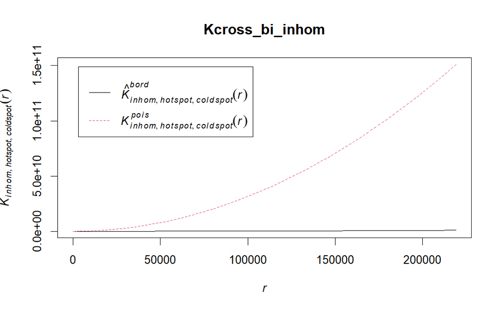

```r
#Se puede explorar una ventana mas grande
rmax_bbox2 <- min_side / 2

# Define la secuencia de r. Se selecciona un número moderado para exploración
rseq_bbox2 <- seq(0, rmax_bbox2, length.out = 50) # 50 valores

#O se puede probar con otra escala que propone el
rmax_bi <- maxnndist(pp_bi)
rseq_bi <- seq(0, rmax_bi, length.out = 100)

#
Kcross_bi_inhom <- Kcross.inhom(
  X         = pp_bi,
  i         = "hotspot",
  j         = "coldspot",
  lambdaI   = lambda_im,
  lambdaJ   = lambda_im,
  r         = rseq_bbox,
  correction = "border"
)

plot(Kcross_bi_inhom)
```

Se grafica en ggplot

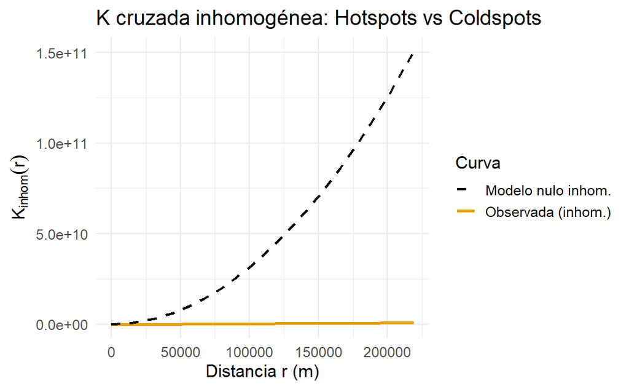

```r
# Convierte el resultado en tibble si no lo has hecho
Kcross_bi_inhom_df <- as_tibble(Kcross_bi_inhom)

# Grafica la función Kcross inhomogénea
p_kcross_inhom <- ggplot(Kcross_bi_inhom_df, aes(x = r)) +
  geom_line(aes(y = border, color = "Observada (inhom.)"), size = 1.2) +
  geom_line(aes(y = theo, color = "Modelo nulo inhom."), linetype = "dashed", size = 1) +
  scale_color_manual(
    name = "Curva",
    values = c("Observada (inhom.)" = "#E69F00", "Modelo nulo inhom." = "black")
  ) +
  labs(
    title = "K cruzada inhomogénea: Hotspots vs Coldspots",
    x = "Distancia r (m)",
    y = expression(K[inhom](r))
  ) +
  theme_minimal(base_size = 14)

p_kcross_inhom

#guarda el último gráfico generado
ggsave(here("Figures", "kcross_biv_inhomogeneo.png"),
       plot = p_kcross_inhom,
       width = 8,
       height = 8,
       dpi = 350)
```